# 1.4 Frequency Distributions

## Categorical Variables

**Frequency** (**count**): the number of times a particular value occurs.

A **frequency distribution** lists each distinct value with its frequency.

| Class | Frequency |
| --- | --- |
| freshman | 12 |
| sophomore | 10 |
| junior | 3 |
| senior | 5 |

A **bar plot** is a graphical representation of a frequency distribution. Each bar’s height is based on the frequency of the corresponding category.

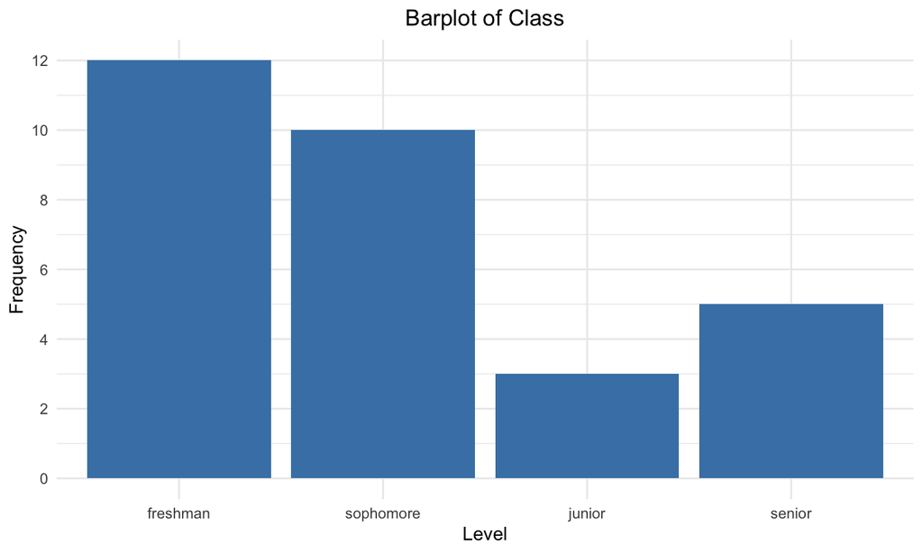

## Relative Frequencies

**Relative frequency** is the ratio of the frequency to the total number of observations.

\[ \text{relative frequency} = \frac{\text{frequency}}{\text{number of observations}} \]

This is also called the **proportion**.

The **percentage** can be obtained by multiplying the proportion by 100.

## Relative Frequency Distribution

A **relative frequency distribution** lists each distinct value with its relative frequency.

| Class | Frequency | Relative Frequency |
| --- | --- | --- |
| freshman | 12 | \(12/30 = 0.4\) |
| sophomore | 10 | \(0.3333\) |
| junior | 3 | \(0.1\) |
| senior | 5 | \(0.1667\) |

## Numeric Variables

A **dot plot** shows a number line with dots drawn above the line. Each dot represents a single observation.

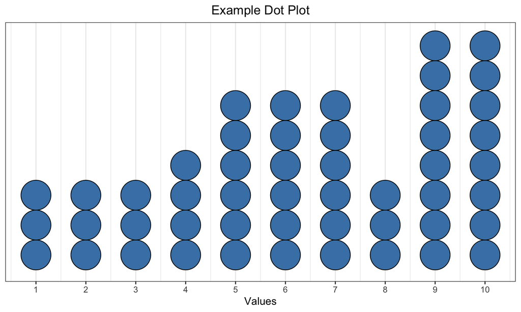

## Binning Complex Data

- We would also like to be able to visualize larger, more complex data sets.
- This is hard to do using a dot plot!
- Instead, we can do this using **bins**, which group numeric data into equal-width consecutive intervals.

## Example

A random sample of weights (in lbs) from 12 cats:

\[\quad 6.2 \quad 11.6 \quad 7.2 \quad 17.1 \quad 15.1 \quad 8.4 \] \[\quad 7.7 \quad 13.9 \quad 21.0 \quad 5.5 \quad 9.1 \quad 7.3 \]

- **Minimum** is 5.5
- **Maximum** is 21

Lots of ways to break these into “bins”, but what about…

- 5 - 10
- 10 - 15
- 15 - 20
- 20 - 25

## Example

We’ve suggested bins

- 5 - 10
- 10 - 15
- 15 - 20
- 20 - 25

Each has an equal width of 5 (that’s good), but if we had a cat with a weight of exactly 15 lbs, would we use the second or third bin??

## Example

To make this clear, we need there to be no overlap. Instead, we could use:

| Weight | Count |
| --- | --- |
| 5 - <10 | 7 |
| 10 - <15 | 2 |
| 15 - <20 | 2 |
| 20 - <25 | 1 |

Now, a cat with a weight of 15.0 lbs would be placed in the third bin (but not the second).

## Example

We will visualize this using a **histogram**, which is a lot like a bar plot but for numeric data:

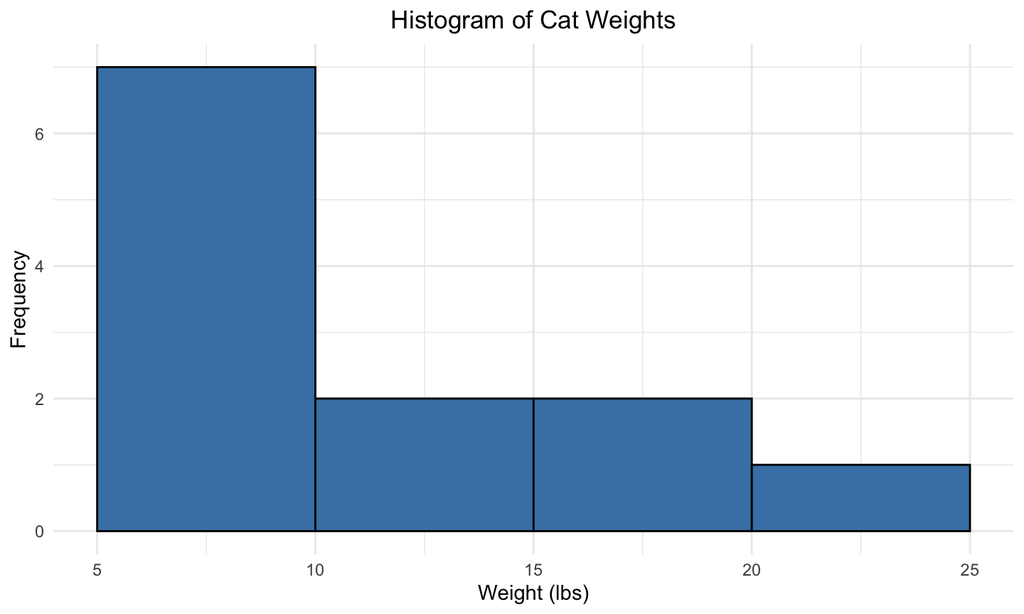

[figure not shown]

This is a **frequency histogram** because each bar height reflects the frequency of that bin.

We can also create a **relative frequency histogram** which displays the relative frequency instead of the frequency:

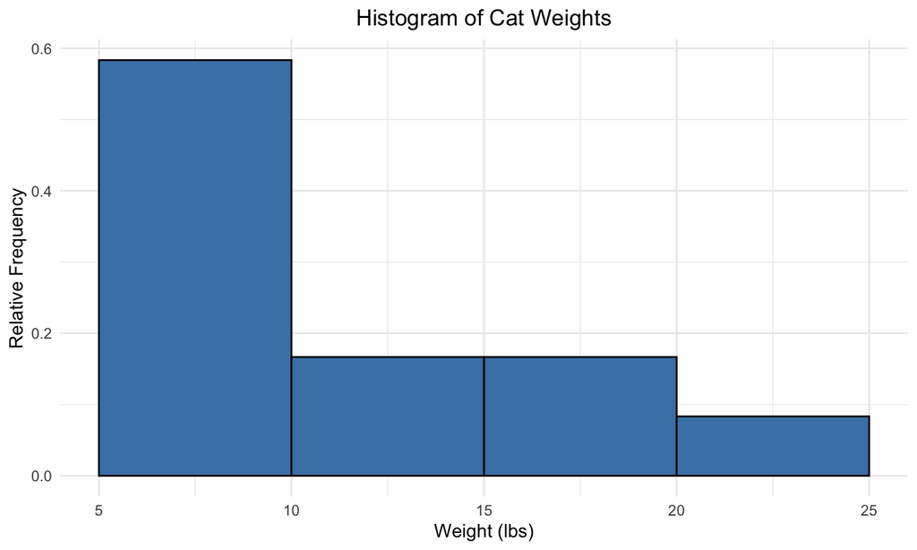

Notice that those last two histograms look the same *except for the numbers on the vertical axis*!

- This gives us insight into the shape of the data **distribution**, literally how the values are distributed across the bins.
- The part of the distribution that “trails off” to one or both sides is called a **tail** of the distribution. - When a histogram trails off to one side, we say it is **skewed**.
  - right-skewed if it trails off to the right
  - left-skewed if it trails off to the left
- Data sets with roughly equal tails are **symmetric**.

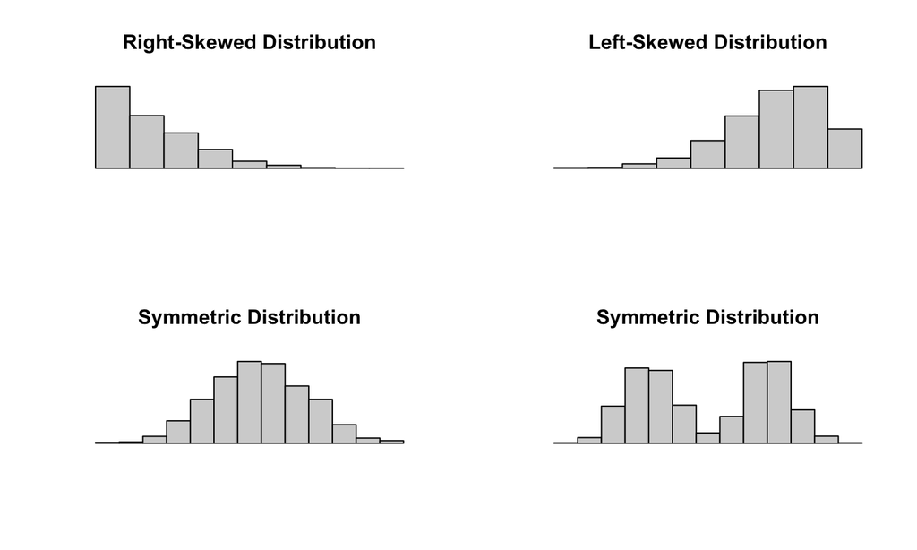

We can also use a histogram to identify **modes**.

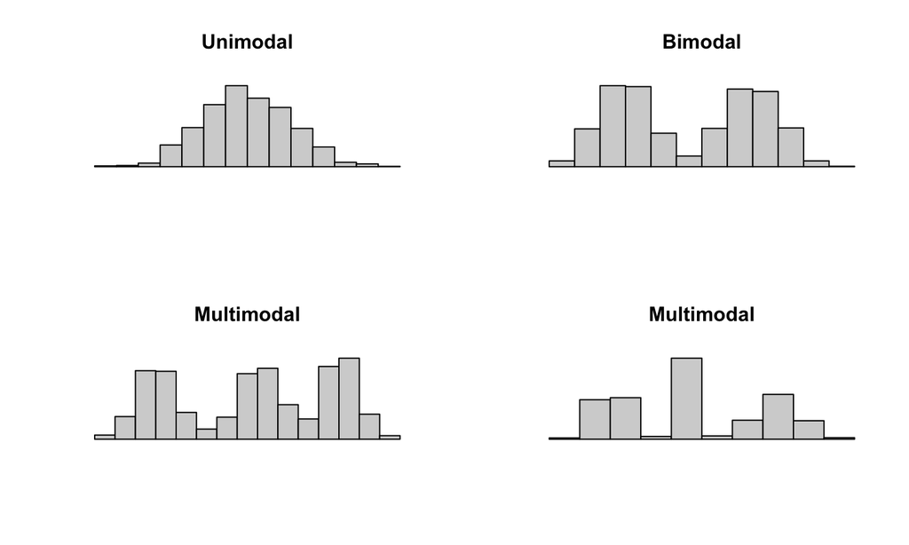

For numeric data, especially continuous variables, we think of modes as *prominent peaks*.

Finally, we can also “smooth out” these histograms and use a smooth curve to examine the shape of the distribution.

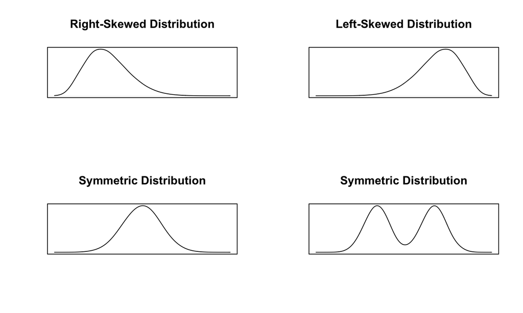